# A Random Forest Model for Computer-Assisted Activity-Recognition

Elizabeth Ash

May 5, 2016

\newpage

First Reader: Dr. Homer White

Second Reader: Dr. David Bowman

\newpage \begin{center} Abstract \end{center}

> We use predictive models to create a statistical model of future behavior. In particular, we examine how well a random forest predictive model would predict the classification of a new lift by the same experimental subjects. We separate the data into training and test sets using the variable `num_window` to ensure that a single lift is not in both sets. We find that a random forest model can accurately and ‘honestly’ predict the classifications of the weight lift type performed by the experimental subjects.

\newpage

# Introduction and Overview

Predictive modeling is a process used to create a statistical model of future behavior. A predictive model is made up of a number of **predictors**, which are variable factors that are likely to influence future behaviors or results. Gareth James, Daniela Witten, Trevor Hastie and Robert Tibshirani give an example in their book *An Introduction to Statistical Learning with Applications in R* to briefly introduce the topic of predictor variables:

> Suppose we are statistical consultants hired by a company to provided advice on how to improve sales of a particular product…It is not possible for our client to directly increase the sales of the product. On the other hand, they can control the advertising expenditure in each of the three media [TV, radio and newspapers]. Therefore, if we determine that there is an association between advertising and sales, then we can instruct our client to adjust advertising budgets, thereby indirectly increasing sales. In other words, our goal is to develop an accurate model that can be used to predict sales on the basis of the three media budgets (James, 2013).

In this example, James, et al. use media budgets for TV, radio, and newspapers as the predictor variables and the sales of a particular product is the response variable. Using predictive modeling, the company can then use the predictor variables to predict the sales outcomes of the particular product.

In predictive modeling, data is collected for the relevant predictors, a statistical model is formulated, predictions are made, and the model is revised as additional data becomes available. My research project deals with predictive models and applications of such modeling.

An example of an application of predictive modeling is activity recognition. Activity recognition is an increasingly important technology because it can be applied to many real-life problems such as, home-based proactive and preventive healthcare applications. It can also be applied in learning environments, security systems, and a variety of human-computer interfaces. The goal of activity recognition is to recognize common human activities in real-life settings.

One real-life setting example of activity recogniton is physical activity, which is one of the most important things that can be done for overall health. It can help control weight, lower risk for heart disease, strengthen bones and muscles, and increase chances of longer life. However, if the activity is performed incorrectly, there is a greater risk of injury, which is counterproductive. To benefit most from a fitness routine, the activity should be performed as accurately as possible. Some people can go to a gym and work with a certified trainer, but many people cannot or will not work with a personal trainer. These people may be doing the correct exercise motion, but there is no way to really know unless they are taught the correct motion by a professional. Using other physical activities as predictor variables, a predictive model could be made and used to help determine if the exercise motion is being executed properly.

In the case of my research project, I want to see if a predictive model can be made to recognize certain weight lift motions. If a predictor model could be made, then the model could be integrated into the weight lift equipment and used to determine if the lift was done correctly or incorrectly. This model could be integrated with other technologies and be used to help reinforce the correct weight lift motion by commending the user for a correct movement or making a comment when the user made an incorrect movement. For example, I am trying to perform the lift motion from the study correctly, but I am actually performing an error. If my predictive model is good enough (based on the measurements from the sensors, the model can accurately predict in which class my lift belongs), then my armband could beep, notifying me of my error.

## Background on Data Used

The article *Qualitative Activity Recognition of Weight Lifting Exercises* describes a study presented by Eduardo Velloso, Andreas Bulling, Hans Gellersen, Wallace Ugulino, and Hugo Fuks. Among other goals, the researchers wanted to provide feedback to weight lifters using qualitative activity recognition. The study involved six male subjects, all in their twenties and with little weight lifting experience. The subjects were taught how to lift a dumb-bell correctly and were also taught how to perform the same movement in four incorrect ways. The Unilateral Dumbbell Bicep Curl was the lift that was taught to the subjects. The five categories of lift data collected were:

```
* Class A: correct lift movement
* Class B: throwing the elbows to the front
* Class C: lifting the dumbbell only halfway
* Class D: lowering the dumbbell only halfway
* Class E: throwing the hips to the front
```

The subjects repeated each lift ten times and during each lift the researchers recorded a number of inertial measurements from sensors in the users’ glove, armband, lumbar belt, and dumbbell (these are pieces of equipment that are commonly used by weight lifters). These measurements make up the predictors that the researchers used when determing a correct or incorrect lift. The sensors recorded several data points throughout the lifting motion and the final data set includes 160 variables. Some of the variables included are: user_name, num_window, yaw_belt, pitch_belt, and total_accel_belt.

The aim of this report is to build a predictive model that can be used in realistic circumstances built on the data from the Velloso et al study.

\newpage

# Methods

## Background on Methods Used

The method of model making that will be used in this report is random forest. A more detailed discussion of the random forest method will follow. However, there are some concepts and definitions that need to be addressed before the random forest method can be fully understood. The first important concept is a classification tree, which is used in the construction of a random forest model.

## Classification Trees

Classification trees are a tree-based model and are used to predict a qualitative response. The variables that go into these classification trees can be numerical or categorical. We predict that “each observation belongs to the most commonly occuring class (or category) of training observations in the region to which it belongs” (James, 2013). They are useful because they provide predictors in situations where there are many variables that interact in complicated, non-linear ways. In interpreting these classification trees, we are often “interested in both the class prediction corresponding to a particular terminal node region, and in the class proportions among the training observations that fall into that region” (James, 2013).

So, in simpler terms, a classification tree consists of a set of true/false decision rules. It is kind of like a game of 20 questions, where we ask different questions based on the answers to previous questions, and then at the end we make a guess based on all the answers. We can visualize a decision tree as a set of nodes (corresponding to true/false questions), each of which has two branches depending on the answer to the question. Unlike real trees, we usually draw them with their “root” at the top, and the “leaves” at the bottom. In order to make predictions with the tree, we start at the top (the “root” node), and ask questions, traveling left or right in the tree based on what the answer is (left for true and right for false). At each step, we reach a new node, with a new question. Once we reach the bottom (a leaf node), we make a prediction based on the set of answers, just like 20 questions. But unlike 20 questions, the number of questions in a decision tree is not always 20, but can vary (Corso, 2013).

Shall we look at an example of a classification tree?

We are using a data set from a survey taken in the MAT 111 class (Elementary Probability and Statistics) at Georgetown College. This data set has 71 rows and 12 variables. The survey includes variables such as sex, height, GPA, sleep, and the fastest speed ever driven. The names of some of the variables may seem a little odd, such as weight_feel, love_first, and extra_life. The weight_feel variable is how the participant feels about their weight. They could have answered underweight (“a”), about right (“b”), or overweight (“c”). The love_feel variable is whether or not the participant believes in love at first sight and the extra_life variable is whether or not the participant believes in extraterrestrial life. The seat variable is where the participant sits in a classroom. The letter “a” corresponds to sitting in the front, “b” corresponds sitting in the middle rows, and “c” corresponds to sitting in the back rows.

### An Extended Example of a Classification Tree

This tree is used to predict the sex of an individual based on the variables of fastest speed ever driven, GPA, height, the amount of sleep the participant got the night before, how the participant feels about their weight, and if the participant believes in love at first sight. R code is not only a great tool for making classification trees, it can also print a readable version of classification trees. Below is an easy to understand schematic of a classification tree.

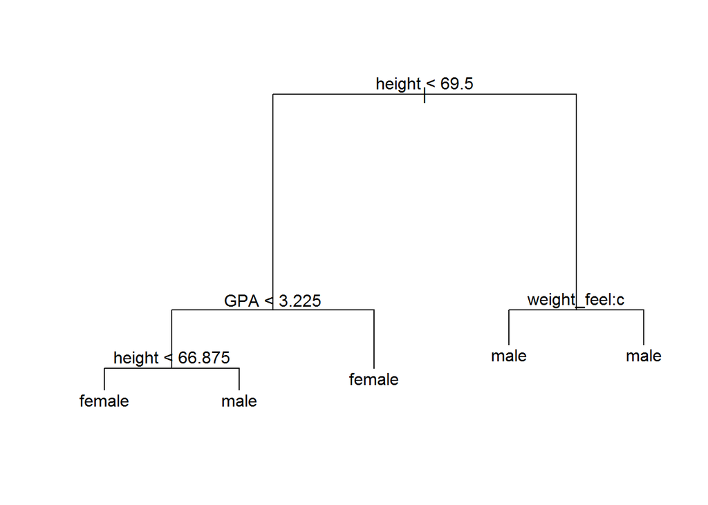

Classification tree to predict sex in m111survey data

All classification trees have nodes. The top node is referred to as the *root* node. Nodes can either split into two *daughter* nodes (or leaves) or they can stop splitting. A node that does not split any further is known as a *terminal* node. In this tree example, the majority sex in each terminal node is given under the node. This tree can be used to predict if a new individual is male or female. All we have to do is ask YES or NO questions and follow the nodes to a terminal node.

Below is the same classification tree, but with more details:

```
node), split, n, deviance, yval, (yprob)
      * denotes terminal node

1) root 70 96.120 female ( 0.5571 0.4429 )
  2) height < 69.5 42 34.450 female ( 0.8571 0.1429 )
    4) GPA < 3.225 18 22.910 female ( 0.6667 0.3333 )
      8) height < 66.875 9  6.279 female ( 0.8889 0.1111 ) *
      9) height > 66.875 9 12.370 male ( 0.4444 0.5556 ) *
    5) GPA > 3.225 24  0.000 female ( 1.0000 0.0000 ) *
  3) height > 69.5 28 19.070 male ( 0.1071 0.8929 )
    6) weight_feel: 3_overweight 10 12.220 male ( 0.3000 0.7000 ) *
    7) weight_feel: 1_underweight,2_about_right 18  0.000 male ( 0.0000 1.0000 ) *
```

This printout actually gives us quite a bit of information about the classification tree. First, the node numbers are labeled. So the root node is number 1 and the daughter nodes are numbers 2 and 3. Second, the variable by which the split was made is given. For example, the root node is split based on height. With daughter node 2, any height less than 69.5 inches would be placed in that node. And for daughter node 3, any height greater than 69.5 inches would be placed in that node. Third, the number of cases that reach the node is given. For example, there are 70 observations in the root node. [As a note, classification trees do not like missing data, so one row from the original data set was removed to avoid any missing values.] After the root node is split, 42 observations are found in daughter node 2 and 28 observations are found in daughter node 3. The sum of the two observations is 70. The fourth piece of information given by the printout is deviance, which is an assessment of goodness of fit (we will go into this a litte later). The fifth piece of information in the prinout is the yval, which is the majority value for the node. This would be predicted for that node. For example, if the tree was forced to make a prediction about the sex at node 4, the tree would predict that the individual would be female. The final piece of information from the printout is the yprob, which gives the probabilities of the variables being predicted. In node 4, (0.6667 0.3333) is given. This means that 66.67% of the objects in the node are female and 33.33% of the objects are male. The yval proportions can also be used to assign a probability to the prediction of a new person. For example, if we were to try to predict the sex of a new individual (using this classification tree) and the tree had to make a guess at node 4, the new individual would be predicted to be female. Female is the majority sex in this node, which is why a female prediction would be made. In addition, the yval proportion of 0.6667 tells us that the tree is 66.67% sure that the new individual is female.

While it is wonderful to be able to recognize a classification tree and use it to make predictions, it is equally important to understand the basic mechanics of how a classification tree works. Such as, how does a tree decide to make a split? Or how does a tree decide when to stop splitting into more daughter nodes? The answer is tree control.

We can control how finely a tree will be made by the `tree.control` function. Let’s look at the R code to get a better understanding of the tree construction:

```
m111s.tr <- tree(sex~fastest+GPA+height+sleep+weight_feel+love_first,
                 data=m111survey,
                 control = tree.control(
                   nobs = nrow(m111survey),
                   mincut = 5,
                   minsize = 10,
                   mindev = 0.01
                 ))
```

There are 4 arguments for this function. The first argument, `nobs`, is the number of observations that will be used to build the tree. In this tree we are using all the rows in the dataset. The other three arguments have a say in whether the tree can continue splitting or not. The second argument, `minsize`, is the smallest allowed node size. The next argument, `mincut`, is the minimum number of observations to include in either post-division node. This means that any daughter node must be at least the size of the `mincut` value. Another small note to know, the `mincut` value cannot be more than half of the `minsize` value. The final argument of the function is `mindev`. The *within-node deviance* must be at least the `mindev` valude times that of the root node for the node to be split. This means that for a division to be made, the deviance of the node that we are thinking of splitting must be at least the value of `mindev` times the deviance of the root node. At each split, the deviance is determined. Each node has a deviance value, and this is considered the *within-node deviance*.

The default settings for the `tree.control` function are:

- `mincut` = 5,
- `minsize` = 10,
- `mindev` = 0.01

Even though these are the default values, they can be changed and this will change the final construction of the classification tree. As an example, if we set `mindev` to 0 and `minsize` to 2, `mincut` to 1, a tree that fits the data perfectly will be produced. With these settings, a tree can be made with a large number of terminal nodes that are small in size and very near to pure. Changing the default settings to lower values produces trees that are larger and can possibly make fewer errors (on the data already given). However, even though the terminal nodes are pure, any chance variation may be seen as patterns. This does not make for good predictions on new data and the model will not be useful for predicting on any other data set than the one it was made with.

Now, let’s take a closer look into how deviance is found and why it is so important.

The general deviance formula used for the classification trees is:

$$-2 \sum_{k}n_{k}\ln(p_{k})$$

where:

- k stands for the $k^{\text{th}}$ possible value
- $n_{k}$ is the number of a certain type in node k
- $p_{k}$ is the proportion of a certain type in node k

*Recall: $\ln{x}$ is the natural logarithm of the value x*

*Note: When $p_{k}$ = 0 the entire term is defined as 0*

\newpage

For example, the deviance for any node of this classification tree would be found in the following way:

$$D = -2[(n_{1}\ln(p_{1})) + (n_{2}\ln(p_{2}))]$$

where:

- $n_{1} = \texttt{number of females in the node}$
- $n_{2} = \texttt{number of males in the node}$
- $p_{1} = \texttt{proportion of females in the node}$
- $p_{2} = \texttt{proportion of males in the node}$

We can now begin looking at how this formula can work. As stated earlier, deviance is a measure of goodness of fit. In other words, the deviance is a measurement of purity. The more pure a node is (or in the case of our tree, the closer the node is to being all male or all female), the closer the deviance is to 0. Thus, when deciding on whether to make a split at a node or not, is to choose a split such that the sum of the deviance of the two daughter nodes is smaller than the deviance before the split. In fact, the tree will find a split so the sum of the two daughter nodes is as small as possible. Now, `mindev` sets a limit on how small the deviance can be. In order to split into daughter nodes, the deviance of the node which will be split must be at least
$$\texttt{mindev}\times\textbf{root deviance}$$
[Recall that the default value for `mindev` is 0.01, but this can be changed to modify the tree growth.]

To show how this would work, let’s look at the split of the root node. If you look at the printout of the classification tree, you can see that the deviance before the split was 96.120 (the deviance of root node).

```
1) root 70 96.120 female ( 0.5571 0.4429 )
  2) height < 69.5 42 34.450 female ( 0.8571 0.1429 )
  3) height > 69.5 28 19.070 male ( 0.1071 0.8929 )
```

Before a node can be split into daughter nodes, a few things must be considered. First, in order for the root node to be divided into two new nodes, the deviance must be at least 0.96 (since the deviance must be at least 0.01 times the deviance of the root node before splitting). Well, the deviance of the root node will be at least 0.96, so this is a trivial calculation. Second, the node must be at least size 10 (our default `minsize` value). If these two conditions are satisfied then the tree will think about splitting the node.

So using the classification tree example, let’s look at a different, nontrivial, example of how the deviance was found. How about node 4? Below is the printout of node 4 with the two daughter nodes:

```
4) GPA < 3.225 18 22.910 female ( 0.6667 0.3333 )
  8) height < 66.875 9  6.279 female ( 0.8889 0.1111 ) *
  9) height > 66.875 9 12.370 male ( 0.4444 0.5556 ) *
```

If you look at the original print out of the classification tree, you will notice that there are 18 participants before this split is made; 12 female and 6 male. To find how many females or males are in the node, take the `nobs` value and multiply it with the `yprob` values (the proportions given). The nearest integer is the number of females or males in the node. So,

Females = $\texttt{18}\times\texttt{0.6667}$ = 12

Males = $\texttt{18}\times\texttt{0.3333}$ = 6

\newpage

Let’s verify the deviance given for this node using our formula.

$$D = -2[(12)(\ln(\frac{12}{18})) + (6)(\ln(\frac{6}{18}))]$$

$$D = 22.914$$

Since the deviance is greater than 0.96 (the deviance must be at least 0.01 times the deviance of the root node before splitting), we can think about splitting into daughter nodes. Also, since the size of the node is 18, which is greater than 10, we can think about splitting into daughter nodes.

Notice that the daughter nodes are at least equal to 5, which is the `mincut` value. Both daughter nodes had size 9. If either of the daughter nodes had been less than size 5, then the split would not have been made.

Now if we look at the deviance of each side of the split and add them together, the sum should be less than 22.914, since a split looks for the smallest total deviance.

$$D_1 = -2[(8)(\ln(\frac{8}{9})) + (1)(\ln(\frac{1}{9}))] = 6.279$$

$$D_2 = -2[(4)(\ln(\frac{4}{9})) + (5)(\ln(\frac{5}{9}))] = 12.365$$

$$D_1 + D_2 = 18.644$$

If the sum of the two daughter nodes was larger than 22.914, then a split would not be made because it would not improve the total deviance of the classification tree.

Of all the possible splits, where both daughter nodes have a larger size than the `mincut` value, this was the smallest deviance found, which is why the tree made this particular split. The tree made a split because there was a way to make the total deviance smaller.

As a final example of the tree making splits, recall that the tree had two terminal nodes (from the same split) that are both male.

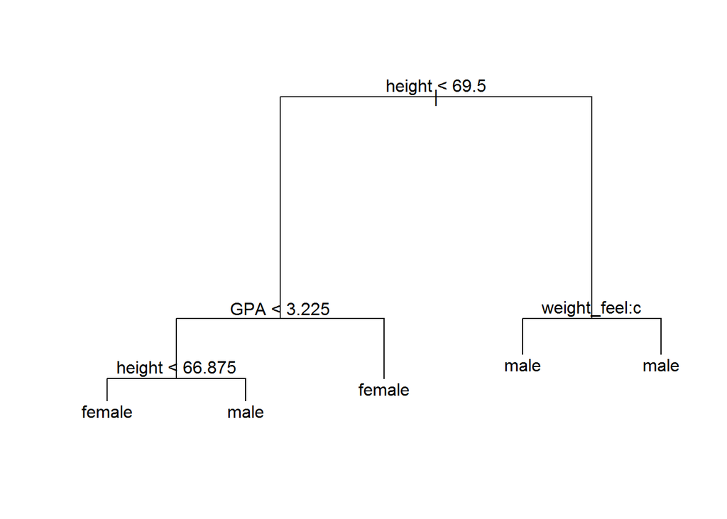

```
3) height > 69.5 28 19.070 male ( 0.1071 0.8929 )
    6) weight_feel: 3_overweight 10 12.220 male ( 0.3000 0.7000 ) *
    7) weight_feel: 1_underweight,2_about_right 18  0.000 male ( 0.0000 1.0000 ) *
```

Below is a summary of the classification tree example from above.

```
Classification tree:
tree(formula = sex ~ fastest + GPA + height + sleep + weight_feel +
    love_first, data = m111survey)
Variables actually used in tree construction:
"height"      "GPA"         "weight_feel"
Number of terminal nodes:  5
Residual mean deviance:  0.4748 = 30.86 / 65
Misclassification error rate: 0.1143 = 8 / 70
```

The summary given shows the variables actually used in constructing the classification tree, the number of terminal nodes, the residual mean deviance, and the misclassification error rate.

In order to find the residual mean deviance, R added the deviance at all 5 terminal nodes and then divided by (number of observations - number of terminal nodes). This is a very difficult number to interpret. The main thing to understand is that the smaller the residual mean deviance, the more “pure” the nodes are on average. Thus,

$$Residual Mean Deviance = \frac{30.869}{70-5} = 0.4749$$

The residual mean deviance (RMD) is also used to compare two different tree models and how well they predict. The smaller the value of the residual mean deviance, the better the tree is at predicting on its own data. For example, if I have one tree model used to predict the sex of individual using one dataset and another tree model used to predict if an individual is at risk for diabetes using a different dataset, the residual mean deviance could be used to compare how well the models will predict on its own data. If the RMD of the first model is 0.4749 and the RMD of the second model is 0.5812, then we know that the first model is better at making predictions.

The final output given by the classification tree summary is the misclassification error rate. The performance of a model is measured in terms of its misclassification error rate: percentage of incorrectly classified instances in the data set (Witten and Eibe, 2000). The lower the misclassification error rate, the higher the performance of the model. In other words, a lower misclassification rate means that a smaller number of objects are being misclassified and the model is making correct predictions.

As you can see from the example, classification trees are easy to interpret and fairly good predictions can be made from them. In this example, the misclassification error rate is about 11.4%. This means that 8 out of 70 observations were misclassified. However, the tree is looking at correct answers that were given. If this classification tree were given new data, the error rate would most likely be much worse.

Unfortunately, R has some round-off error. This is why the values calculated are slightly off from the summary.

## The Need for Test Sets

Why not use all the data from the data set? Then more data will be available to make the model and the model will be more accurate, right? Actually, this is incorrect. The *resubstitution error* (error rate on the training set) is a bad predictor of performance on new data because the model was built to account for the training data. The best model for predicting is the dataset itself. So, if you take a given data instance and ask for it’s classification, you can look that instance up in the dataset and report the correct result every time. You are asking the model to make predictions to data that it has “seen” before- data that were used to create the model. Thus, to really know if the model would be a good predictor of the weight lift motion, it must be measured on the test data set (the data it has never “seen” before), not the training set.

Now we’re ready to look more at a random forest model and what it does.

## Random Forests

### History and Author

The algorithm that is used to induce random forests was developed by Leo Breiman and Adele Cutler in 2001. Leo Breiman was a distinguished statistician at the University of California, Berkeley. Breiman’s work helped to bridge the gap between statistics and computer science, particularly in the field of machine learning. His most important contributions were his work on classification trees and ensembles of trees through the random forest technique. Adele Cutler is a statistician at the University of Utah. Leo Breiman was her PhD advisor and they worked together to come up with the random forest technique that is most commonly used today (Wikipedia).

Even though Breiman and Cutler created the algorithm for random forests, the concept of random forest decision trees was first introduced to the mathematical community by Tin Kam Ho of Bell Labs in 1995. The term for random forests came from Ho’s random decision forests. The development of Breiman’s algorithm was influenced by Ho’s work with random subspace selection (Ho, 1995). Brieman was also influenced by the work of Yali Amit and Donald Geman, who introduced the idea of searching over a random subset of the available decisions when splitting a node, in the context of growing a single tree (Amit & German, 1997). The algorithm combines Breiman’s ideas and the random selection of features in order to construct a collection of decision trees with controlled variance. Thus, in Brieman’s method a forest of trees is grown, and variation among the trees is introduced by projecting the training data into a randomly chosen subspace before fitting each tree (Breiman, 2001).

A random forest package was published for R by Andy Liaw and Matthew Wiener, based on original Fortran code by Leo Breiman and Adele Cutler. The following links to a PDF document for further information on the `randomForest` R package:

https://cran.r-project.org/web/packages/randomForest/randomForest.pdf

### How Random Forests Work

#### Tree Splitting

Random forests are a way of averaging multiple classification trees, which are trained on different parts of the same training set. However, there are some major differences in the classification trees used in a random forest compared to a regular classification tree. First, at any point where the tree is thinking of a split, the tree does not look at all the predictor variables. Instead, a random subset of the predictor variables is picked. At each node, $\sqrt{n}$ (where n is the number of predictor variables) predictor variables are picked. The floor of $\sqrt{n}$ is the number of predictor variables picked. This means that a number is given as the largest integer that is less than or equal to $\sqrt{n}$. While the regular tree examines every predictor variable at each node and picks the one that will give the best prediction, the random forest tree looks at $\sqrt{n}$ of predictor variables at each node and then picks the one that will give the best prediction. Also, this means that most trees in the random forest are different. We want the trees to differ from one another. They will make errors, but they will be errors in different directions, so to say. The hope is that the different trees will “cancel out” the error.

As an example, we will look at the weight lifting data. There are over 100 different predictor variables in this dataset. However, in a later section I will do some data cleaning and remove predictor variables that are not actually useful. The data cleaning process will leave me with 53 variables. Thus, in the random forest procedure, whenever a tree is thinking about splitting at a node, floor($\sqrt{53}$) predictor variables will be used. Since ($\sqrt{53}$) is 7.28011, the tree will look at 7 of the 53 predictor variables.

#### Tree Size

A second important difference between random forest classification trees and regular classification trees is the size. Random forest classification trees are overgrown. In a regular classification tree the `mincut` is set at 5. In random forests we are looking at trees with nodes that end up being very small- one or two objects in the final nodes. One example of the arguments in the `randomForest` package is `nodesize`. This is the minimum size of terminal nodes. The default for the classification trees in `randomForest` is 1.

[Note: There is a `treesize` package that controls tree size in regular classification trees. There is also a `randomForest` package argument that controls the tree size in the random forest classification trees- `nodesize`]

Thus, larger trees are grown because the terminal nodes can have a minimum of 1 object. This overgrowing of classification trees allows for great variability in the classification trees. Most of the classification trees will not be able to make predictions well on new data. In fact, many will have strange results. Even though an individual overgrown tree may closely describe the training data, the tree will not give good results on new data because it is tracking chance variation as pattern. However, putting together all the trees can actually give good results. The trees are all tracking chance variation in different directions and by putting them together the extreme results can be “cancelled out”.

#### Tree Building

A third difference that needs to be considered is the fact that the classification trees used to build a random forest do not use the entire training data. Rather, they select at random, with replacement, from the training data. This random sample size is equal to the size of the original training data set. Since each tree does not use the entire training data, this gives variability that we want to take into account when making a model. The training data set resembles a sample of all the possible measurments. So, let’s think about the weight lifting data which I will use later. The weight lifting data are like a random sample of the data we could have gotten while taking measurements of the weight lifting subjects. Overall, we want to try to reflect chance variations in real-life measurements. However, we don’t have all the possible observations. We only have the weight lifting data set as an approximation. So taking a sample of the data we have is the best approximation we have to taking another sample in a real life population. Therefore, taking many samples (and most of them end up being different from each other) is the best way to see how trees depend on chance variation and this variablitity is incorporated into random forests. Thus, once again, errors are made but we hope the differences in the random samples “cancel out” those errors to provide a fairly good model for predictions.

The concept of a random sample with the sample size equal to the number of observations in a set may seem a little confusing at first. Let me illustrate this concept with a simple example:

I will take a random sample, with replacement, from the numbers 1 through 100. I begin with a list of the first 100 numbers and I put them in a bag (this is my original data set). I draw out a number from the bag and write it down. I replace the number, pick from the bag again, and write down the number I’ve drawn. I replace the number and continue in this way until I have a new list of 100 numbers (this is the sample data set). The new list may have duplicate numbers or some numbers may be missing entirely. This new list is an example of what it would be like to take a random sample from those 100 numbers.

I have made a list of 100 numbers and taken a random sample from the original list.

```
"27" "11" "97" "36" "64" "4"  "9"  "6"  "71"  "25"
"52" "82" "3"  "62" "66" "45" "2"  "3"  "99"  "14"
"66" "23" "37" "34" "92" "46" "96" "69" "61"  "84"
"17" "44" "36" "86" "9"  "58" "52" "59" "84"  "45"
"19" "66" "60" "37" "37" "61" "11" "81" "100" "46"
"10" "49" "60" "79" "21" "62" "21" "89" "22"  "54"
"2"  "75" "33" "56" "67" "14" "9"  "58" "31"  "25"
"89" "95" "39" "51" "45" "96" "23" "36" "87"  "35"
"72" "8"  "46" "94" "31" "97" "7"  "30" "46"  "32"
"46" "56" "16" "28" "16" "80" "72" "40" "47"  "4"
```

Notice that some of the numbers have been repeated and some numbers are missing. We can have the computer look at the numbers we are missing and the numbers that are included in the random sample.

\newpage

Below is a table showing the numbers that are missing from the random sample:

```
 "1"  "5"  "12" "13" "15" "18"
 "20" "24" "26" "29" "38" "41"
 "42" "43" "48" "50" "53" "55"
 "57" "63" "65" "68" "70" "73"
 "74" "76" "77" "78" "83" "85"
 "88" "90" "91" "93" "98"
```

Below is a table showing the numbers that are part of the random sample:

```
 "27" "11" "97" "36"  "64" "4"  "9"  "6"  "71" "25"  "52"
 "82" "3"  "62" "66"  "45" "2"  "99" "14" "23" "37"  "34"
 "92" "46" "96" "69"  "61" "84" "17" "44" "86" "58"  "59"
 "19" "60" "81" "100" "10" "49" "79" "21" "89" "22"  "54"
 "75" "33" "56" "67"  "31" "95" "39" "51" "87" "35"  "72"
 "8"  "94" "7"  "30"  "32" "16" "28" "80" "40" "47"
```

Notice that 35 numbers are missing from the new list, which is 35% of the data.

Why don’t we take another sample of 100?

I have made another list of 100 numbers and taken a random sample from the original list.

```
"90" "27" "38" "58" "91" "21" "90" "95" "67"  "63"
"7"  "21" "18" "69" "39" "77" "50" "72" "100" "39"
"78" "94" "22" "66" "13" "27" "39" "2"  "39"  "87"
"35" "49" "60" "50" "19" "83" "67" "80" "11"  "73"
"42" "83" "65" "79" "56" "53" "79" "3"  "48"  "74"
"70" "48" "87" "44" "25" "8"  "10" "32" "52"  "67"
"41" "92" "30" "46" "34" "66" "26" "48" "77"  "9"
"88" "34" "84" "35" "34" "48" "90" "87" "39"  "78"
"97" "44" "72" "40" "33" "76" "21" "72" "13"  "25"
"15" "24" "6"  "65" "88" "78" "80" "46" "42"  "82"
```

Below is a table showing the numbers that are missing from the random sample:

```
 "1"  "4"  "5"  "12" "14" "16"
 "17" "20" "23" "28" "29" "31"
 "36" "37" "43" "45" "47" "51"
 "54" "55" "57" "59" "61" "62"
 "64" "68" "71" "75" "81" "85"
 "86" "89" "93" "96" "98" "99"
```

Below is a table showing the numbers that are part of the random sample:

```
"90"  "27" "38" "58" "91" "21" "95" "67"
"63"  "7"  "18" "69" "39" "77" "50" "72"
"100" "78" "94" "22" "66" "13" "2"  "87"
"35"  "49" "60" "19" "83" "80" "11" "73"
"42"  "65" "79" "56" "53" "3"  "48" "74"
"70"  "44" "25" "8"  "10" "32" "52" "41"
"92"  "30" "46" "34" "26" "9"  "88" "84"
"97"  "40" "33" "76" "15" "24" "6"  "82"
```

Notice that this list is missing 36 numbers from the original list. This means 36% of the original data is missing. In fact, the expected proportion of missing data is about 0.3678 or better known as $\frac{1}{e}$. The number *e* is an important mathematical constant that is the base of the natural logarithm. It is approximately equal to 2.71828. [Note: The history and mathematical importance of the number *e* is not in the scope of this paper, but if you would like to know more I suggest reading “e: the Story of a Number” by Eli Maor (1994).]

Now let’s see what happens when we take a larger sample. Suppose I have a list of numbers 1 to 10,000 instead of only 100. Then, looking at the numbers included in the new list, we find that 3,681 are missing.

```
 "3682" "3674" "3690" "3691" "3727"
 "3696" "3596" "3685" "3716" "3741"
```

Below is the computation done by R to show the value of $\frac{1}{e}$:

```
0.3678794
```

As an added bonus, the random sample with replacement is used to make an estimation of how well the random forest will do. And that estimation will be made even when the random forest is being constructed.

Thus, the random selection of predictor variables, the overgrowing of the trees and the random sample of data allows for many different possibilities, which can help with making predictions. This makes the random forest a very effective modeling tool.

### Summary of How Random Forests Work

This summarizes the information from above.

1. Each tree is trained on roughly $2/3^{\text{rd}}$ of the total training data. Cases are drawn at random with replacement from the original training data. This sample will be the training set for growing the tree. The other $1/3^{\text{rd}}$ of the cases are left out of the sample (recall it will actually be about $\frac{1}{e}$ of the data). For each tree, using the leftover data, the misclassification rate (or out-of-bag error rate) is calculated. The error from all trees is used to determine overall OOB error rate for the classification.This out-of-bag (OOB) data is used to get a running unbiased estimate of the classification error as trees are added to the forest. It is also used to get estimates of variable importance.
2. Some predictor variables (say, m) are selected at random out of all the predictor variables and the best split on these m is used to split the node. By default, m is square root of the total number of all predictors for classification. The value of m is held constant during the forest growing. As explained earlier, in a standard classification tree, each split is created after examining every variable and picking the best split from all the variables.
3. Each tree gives a classification, and we say the tree “votes” for that class. The forest chooses the classification having the most votes over all the trees in the forest. The vote will be YES or NO. All the YES votes are counted and this is the predicted probability for a classification.
4. The classification trees that make up the random forest are overgrown to allow for greater variability in the classification trees. While the individual overgrown trees make poor predictions on data, putting together hundreds of overgrown trees can “cancel out” the extreme results and better predictions can be made.

### An Extended Random Forest Example

Once again we will use all the data from the `m111survey` to construct a random forest. However, for the weight lifting data I will make a division for training and test sets before constructing a random forest.

Below is an example of the code for random forests, along with explanations for each part.

The code for implementing a random forest:

```r
set.seed(1010)
  # set.seed() keeps the results of the code chunk the same. This
  # is useful when reproducible results are desired.

rf.sexm111 <- randomForest(sex~fastest+GPA+height+sleep+
                             weight_feel+
                             love_first+extra_life+ideal_ht+
                             seat+enough_Sleep+diff.ideal.act.,
                             data=m111surv2, ntree=500)
```

The `randomForest` function has several arguments, but only some are used in this example. The first argument, `formula`, is a formula describing the model to be fitted. We want to predict sex of an individual based on the variables of fastest speed ever driven, GPA, height, the amount of sleep the participant got the night before, how the participant feels about their weight, if the participant believes in love at first sight, if the participant believes in extraterrestrial life, the participant’s ideal height, where the participant prefers to sit in class, if the participant believes they got enough sleep the night before and the difference between ideal height and actual height. The structure for the formula is as follows:

```
sex~fastest+GPA+height+sleep+
     weight_feel+
     love_first+extra_life+ideal_ht+
     seat+enough_Sleep+diff.ideal.act
```

The next argument is `data`. This is the data frame containing the variables in the model. As stated earlier, the data frame for this example is taken from the MAT 111 Survey data.

The final argument used in this example is `ntree`, which is the number of trees to grow. The default number of trees to be grown for the random forest is 500, but this can be adjusted.

The random forest is put into an object,`rf.sexm111`, thay way we don’t have to write out all the components every time we want to implement the random forest. Also, `set.seed` is used to reproduce the results of the random forest output. In other words, each time the code is executed the results will be the same.

\newpage

Now that the code has been written out, we can take a look at the results. Below is the output given by running the random forest code:

```
randomForest(formula = sex ~ fastest + GPA + height + sleep +
weight_feel + love_first + extra_life + ideal_ht + seat +
enough_Sleep + diff.ideal.act., data = m111surv2, ntree = 500)

Type of random forest: classification

Number of trees: 500

No. of variables tried at each split: 3


OOB estimate of  error rate: 4.41%

Confusion matrix:
       female male class.error
female     37    1  0.02631579
male        2   28  0.06666667
```

Let’s talk about what happened bit by bit. Recall that the `randomForest` function is stored in an object (`rf.sexm111`) and R prints out the object as output with several different components.

First, is the `call` which is the original call to `randomForest`, or the code to implement the function.

```
randomForest(formula = sex ~ fastest + GPA + height + sleep +
weight_feel + love_first + extra_life + ideal_ht + seat +
enough_Sleep + diff.ideal.act., data = m111surv2, ntree = 500)
```

Second, the `type` is given. This refers to the types of trees that were grown for the random forest. Trees are usually grown as classification or regression trees. However, it is not necessary to understand the difference between the two for our purposes. In this example, the trees are classification trees.

```
Type of random forest: classification
```

Third, the number of tres grown, `ntree` is given. The default number is 500. However, depending on the model this number can be changed.

```
Number of trees: 500
```

We can actually look at some of the individual trees constructed for the random forest and see some of the differences between them:

\newpage

Tree 1 made by the Random Forest

| LD | RD | split var | split point | status | prediction |
| --- | --- | --- | --- | --- | --- |
| 2 | 3 | GPA | 3.715 | 1 | NA |
| 4 | 5 | ideal_ht | 71.000 | 1 | NA |
| 0 | 0 | NA | 0.000 | -1 | female |
| 6 | 7 | height | 66.875 | 1 | NA |
| 8 | 9 | height | 77.000 | 1 | NA |
| 0 | 0 | NA | 0.000 | -1 | female |
| 10 | 11 | weight_feel | 1.000 | 1 | NA |
| 0 | 0 | NA | 0.000 | -1 | male |
| 12 | 13 | weight_feel | 2.000 | 1 | NA |
| 0 | 0 | NA | 0.000 | -1 | male |
| 14 | 15 | seat | 1.000 | 1 | NA |
| 0 | 0 | NA | 0.000 | -1 | male |
| 0 | 0 | NA | 0.000 | -1 | female |
| 0 | 0 | NA | 0.000 | -1 | male |
| 0 | 0 | NA | 0.000 | -1 | female |

The *left daughter (LD)* and the *right daughter (RD)* are the two nodes that are made by a division. The *split var* is the variable for which the division was made. The *split point* is the point where the split was made. The *status* shows if more divisions will be made (1) or if a node is terminal (-1). And then the final column shows the prediction of a terminal node. This is true for the two other tables shown below.

Tree 250 made by the Random Forest

| LD | RD | split var | split point | status | prediction |
| --- | --- | --- | --- | --- | --- |
| 2 | 3 | height | 66.875 | 1 | NA |
| 4 | 5 | ideal_ht | 72.500 | 1 | NA |
| 6 | 7 | diff.ideal.act. | 1.750 | 1 | NA |
| 0 | 0 | NA | 0.000 | -1 | female |
| 0 | 0 | NA | 0.000 | -1 | male |
| 8 | 9 | weight_feel | 1.000 | 1 | NA |
| 0 | 0 | NA | 0.000 | -1 | male |
| 0 | 0 | NA | 0.000 | -1 | male |
| 10 | 11 | height | 72.500 | 1 | NA |
| 0 | 0 | NA | 0.000 | -1 | female |
| 0 | 0 | NA | 0.000 | -1 | male |

\newpage

Tree 500 made by the Random Forest

| LD | RD | split var | split point | status | prediction |
| --- | --- | --- | --- | --- | --- |
| 2 | 3 | extra_life | 1.00 | 1 | NA |
| 4 | 5 | ideal_ht | 69.00 | 1 | NA |
| 6 | 7 | ideal_ht | 70.00 | 1 | NA |
| 0 | 0 | NA | 0.00 | -1 | female |
| 0 | 0 | NA | 0.00 | -1 | male |
| 8 | 9 | sleep | 4.75 | 1 | NA |
| 0 | 0 | NA | 0.00 | -1 | male |
| 0 | 0 | NA | 0.00 | -1 | female |
| 0 | 0 | NA | 0.00 | -1 | female |

Notice that each tree is different. The variables used for division differ for each tree. One tree may use variables that make the prediction off in one way, but another tree may use variables that make the prediction off in another way. Since 500 trees are used to make up this random forest, the mistakes even out to make a fairly good prediction model.

The fourth component of the output is `mtry`. This is the number of predictors sampled for splitting at each node. The default value for this argument is $\sqrt{n}$.

```
No. of variables tried at each split: 3
```

Recall that whenever a tree is thinking about splitting at a node, floor($\sqrt{n}$) predictor variables will be used. Since $\sqrt{11}$ = 3.3166, 3 variables are tried at each possible split.

Fifth, an error rate is given. Recall that the misclassification rate is calculated using the leftover data using the leftover data from the random sample with replacement and the error from all trees is used to determine overall OOB error rate for the classification.

```
OOB estimate of  error rate: 4.41%
```

The final output of this example is the confusion matrix of the out-of-bag error. This tells us how many times the prediction of sex was correct or incorrect and gives an error rate for each classification.

```
Confusion matrix:

       female male class.error

female     37    1  0.02631579

male        2   28  0.06666667
```

This table shows us that for all the females in the data set, the random forest classified 37 correctly as female and only misclassified one female as male. Also, only two males were misclassified as females.

*This RF was constructed using only a training set. We only have the OOB error rate as an estimate of how it would do on new data. However, with the weight lifting data I will make a division into training and test sets.*

\newpage

## Computing Tools

For this project I use a variety of tools which include R, RStudio, Git, and GitHub.

### Expansion on R-related Tools

R is a programming language and an open source statisical program software environment used for statistical computing. R provides a wide variety of statistical and graphical techniques. R is available as Free Software under the terms of the Free Software Foundation’s GNU General Public License. It compiles and runs on a variety of systems, such as UNIX, Windows, and MacOS.

To learn more about R and its contributors, please visit: https://www.r-project.org/.

R Studio is a free and open source integrated development environment (IDE) for R. This is a programmer’s tool to help make writing and formatting code an easier task.

To learn more about RStudio, please visit: https://www.rstudio.com/.

I am using R Markdown, which is an authoring format that enables easy creation of dynamic documents, presentations, and reports from R. This document format is extremely useful for a statistical paper (which is what I will be working on this year), as it allows me to enter code chunks that are automatically executed as well as add figures, graphs, and charts. This format also allows me to save PDF, HTML, and Word versions of my document. However, this format is not very flexible when it comes to the aesthetics of the document. I cannot easily format my Bibliography nor do I know how to indent paragraphs because I am just beginning to use RMarkdown. If you require certain format for this paper, please understand that it will be very difficult with RMarkdown and I will probably not be able to focus on that until much later.

To learn more about R Markdown, please visit: http://rmarkdown.rstudio.com/.

### Expansion on Git and GitHub

Git is a free and open source distributed version control system designed to handle everything from small to very large projects with speed and efficiency.

To learn more about Git, please visit: https://git-scm.com/.

GitHub is a web-based Git repository hosting service. It offers all of the distributed revision control and source code management (SCM) functionality of Git. Unlike Git, which is strictly a command-line tool, GitHub provides a web-based graphical interface and desktop. It also provides access control and several collaboration features such as bug tracking, feature requests, task management, and wikis for every project. GitHub offers both plans for private repositories and free accounts, which are usually used to host open-source software projects.

To learn more about GitHub, please visit: https://github.com/.

\newpage

# Results

The following sections will go through the implementation of the methods described from earlier.

## Data Cleaning

Many of the following steps for downloading and cleaning the data are taken from the report “Predicting Movement-Types: Quick Model-Making with Random Forests” written by Dr. White.

### Downloading

The main data, along with the examination data, can be downloaded from the web:

> http://groupware.les.inf.puc-rio.br/har

Below is an example of the code used to download, read, and load a data file into R.

```r
weblink <- paste0("http://groupware.les.inf.puc-rio.br/static/WLE/",
                  "WearableComputing_weight_lifting_exercises_biceps",
                   "_curl_variations.csv")
wl <- read.csv(weblink, stringsAsFactors = FALSE)
save(wl, file = "data/wl.rda")
```

### Elimination of Variables

The main data set consists of 19622 observations on 160 variables, including:

- a row-number variable `X`;
- `user_name` (the name of the subject);
- three time-stamp variables;
- two variables, `new_window` and `num_window` related to time-windows;
- 152 numerical measurements derived from the inertial measurement units (IMUs);
- the variable `classe` that records the activity-type.

Many of the variables can be removed because they are not actually useful as predictor variables. For this data set, the row-number variable `X`, the time-stamp variables, and the `new_window` variable are not particularly useful for predicting the lift motion. Also, for many of the variables the values are altogether missing. These variables appear to be summaries of other variables, such as kurtosis, averages, maximums, minimums, skewness values, amplitude values, variances, and standard deviations. Although these summaries may have predictive value, it is difficult to see how to take advantage of this fact, so we will simply exclude all such variables from our training data.

*Note: Kurtosis is a measure of the “tailedness” of the probability distribution of a real-valued random variable* (http://mathworld.wolfram.com/Kurtosis.html)

\newpage

The spurious variables can be eliminated from our data frame. The code for this is as follows:

```r
# This function determines which of the variables have values that are mostly assigned

goodVar <- function(x){
  mostly_assigned <- sum(is.na(x))/length(x) < 0.5
  mostly_nonblank <- sum(x == "")/length(x) < 0.5
  return(mostly_assigned && mostly_nonblank)
}

not_summary_variable <- sapply(wl, FUN = goodVar)
  # This identifies all the variables
  # that do not have missing values.

goodNames <- names(not_summary_variable[not_summary_variable])

keepNames <- goodNames[-c(1,3,4,5,6)]
  # This keeps all the useful variables in
  # the data set and removes the extra variables that are
  # not useful.

wl2 <- wl[,keepNames]
  # All the variables we wish to keep will be put into a new
  # data set so as to preserve the original data set.

wl2$user_name <- factor(wl$user_name)
wl2$classe <- factor(wl$classe)
  # Makes user_name and classe a factor variable
  # because the randomForest function requires factors.

wn <- wl$num_window
  # I will want to separate my data into training and test sets based
  # on the num_window variable.
```

\newpage

## Data Separation

The data set I am working with will have to be divided into two sets (a training set and a test set). The training set is used to build the model and the test set is data that is used to measure the model’s performance by being treated as “new” data. The model made with the training data will be tried out on the “new” test data. When the original data set is separated into the training and test sets, the simplest partition is a two-way random partition, careful to avoid introducing any systematic differences. The reasoning behind this type of division is that the data available for analytics fairly represents the real-world processes and that those processes are expected to remain stable over time (Steinberg, 2014). So, a well-constructed model will perform adequately on the new data.

Why not use all the data from the data set? Then more data will be available to make the model and the model will be more accurate, right? However, if you recall from section 2.3, The Need for Test Sets, this is incorrect. The *resubstitution error* (error rate on the training set) is a bad predictor of performance on new data because the model was built to account for the training data. The best model for predicting is the dataset itself. So, if you take a given instance and ask for it’s classification, you can look that instance up in the dataset and report the correct result every time. In essence, you are asking the model to make predictions to data that it has “seen” before- data that were used to create the model. Thus, to really know if the model would be a good predictor of the weight lift motion, it must be measured on the test data set, not the training set.

Since there are six subjects in the study, a total of 300 lifts were performed and recorded (each subject did 10 repetitions of the 5 lifts). However, during **each** lift the IMU measurements were gathered using a sliding window approach with different lengths (from 0.5 to 2.5 seconds), with a 0.5 second overlap. This resulted in a large data set (over 19,000 observations); a single observation in the data set corresponds to a specific time window for a specific subject performing one of the specified lifts. While the simplest division is to separate the original data set into training and test sets using a random partition (a typical separation), an expanded separation will be done to make the model more “honest”.

I decided to separate my data by window number. In real life we test on a new lift. So, when we divide into test and training sets, we ideally want to keep individual lifts separate- no portion of a lift in the test and training set. Even though there is no way for us to tell when a new lift is beginning, we have the window number which provides long portions of a lift and allows for a separation with little cross-over.

\newpage

Below is a function that has been written for easy separation. The arguments of this function are the data set to be separated and the variable by which the separation will be done. I can then use this function to separate the weight lifting data set into training and test sets by the `num_window` variable.

```r
# Function for separation by variable.

partition_var <- function(data, var){
  vals <- unique(var)
    # Returns a vector that is the same as "var", but with
    # duplicate elements removed.

  n <- length(vals)
    # Gives the size of the "vals" vector.

  m <- floor(2/3*n)
    # This will be used to help separate the data; 2/3 in a training set
    # and 1/3 in a test set.

  bools <- c(rep(TRUE,m), rep(FALSE,n-m))
    # A booliean object that has m TRUE
    # values and n-m FALSE values. Thus it is the same size as "vals".
    # This will be used later to help determine which rows of the
    # "var" data will be included in each set of separation.
    # Since there are m TRUEs, 2/3 of the "vals" will be used in the
    # training set and 1/3 will be used in the test set.

  inTrain <- sample(bools, size = n, replace = FALSE)
    # Since it is not good enough to just
    # take the first 2/3 of the "bools" vector and put it into a training set,
    # a random sample of the "bools" with size n and no replacement is
    # is taken. This includes the same information
    # as "bools", but it has been all mixed up.

  trvals <- vals[inTrain]
    # Gives values to the list of TRUEs from the inTrain
    # random sample. "trvals" includes the "vals" that had been labeled TRUE
    # in the "inTrain" vector.

  vartr <- var %in% trvals
    # A vector of TRUEs and FALSEs. This will label which of the "var" values
    # were TRUE in "trvals".

  tr <- data[vartr,]
    # Training data set- a data frame that includes rows of "vartr".

  tst <- data[!vartr,]
    # Test data set- a data frame that includes rows that are not in "vartr".

  return(list(tr, tst))
    # Since an R function can only return one object, a list of the training and
    # test sets is returned.
}
```

\newpage

Now the data can be separated into the training and test sets and used for a random forest procedure:

```r
set.seed(2020)
  # set.seed() keeps the results of the code chunk the same. This
  # is useful when reproducible results are desired.

results <- partition_var(wl2, wn)
  # I put the num_window variable into a new object, wn

wlTrain <- results[[1]]
  # Since 2 results are given (test and training set),
  # the first result is the training set

wlTest <- results[[2]]
  # The second result is the test set

rf <- randomForest(x = wlTrain[,1:53], y = wlTrain$classe,
                   xtest = wlTest[,1:53], ytest = wlTest$classe)
```

```
Call:
 randomForest(x = wlTrain[, 1:53], y = wlTrain$classe,
              xtest = wlTest[, 1:53], ytest = wlTest$classe)
```

This formula includes the training and the test sets that we created earlier.

```
Type of random forest: classification

Number of trees: 500

No. of variables tried at each split: 7
```

Unsuprisingly, we used 500 classification trees to make up the random forest. Also, since 53 variables are used in the data set, 7 variables were tried at each possible split of the classification trees.

Now, the error rates and confusion matrices are shown below:

Confusion matrix for Training Set

|  | A | B | C | D | E | class.error |
| --- | --- | --- | --- | --- | --- | --- |
| A | 3683 | 1 | 0 | 0 | 0 | 0.0002714 |
| B | 1 | 2348 | 1 | 0 | 0 | 0.0008511 |
| C | 0 | 3 | 2123 | 0 | 0 | 0.0014111 |
| D | 0 | 0 | 5 | 2280 | 0 | 0.0021882 |
| E | 0 | 0 | 0 | 2 | 2553 | 0.0007828 |

```
OOB estimate of  error rate: 0.1%
```

\newpage

Confusion matrix for Test Set

|  | A | B | C | D | E | class.error |
| --- | --- | --- | --- | --- | --- | --- |
| A | 1857 | 38 | 1 | 0 | 0 | 0.0205696 |
| B | 29 | 1379 | 39 | 0 | 0 | 0.0469938 |
| C | 3 | 134 | 1143 | 13 | 3 | 0.1180556 |
| D | 0 | 0 | 31 | 889 | 11 | 0.0451128 |
| E | 0 | 8 | 0 | 16 | 1028 | 0.0228137 |

```
Test set error rate: 4.92%
```

For your reference, here is a list of the lift types:

```
* Class A: correct lift movement
* Class B: throwing the elbows to the front
* Class C: lifting the dumbbell only halfway
* Class D: lowering the dumbbell only halfway
* Class E: throwing the hips to the front
```

Notice that very few misclassification errors are made on the training set—13 errors out of thousands of classifications. However, when looking at the confusion matrix for the test set, many more errors are made. For example, in the first confusion matrix, the model only made 3 errors when classifying a lift as a Class C error (misclassified it as a Class B error). The overall class error rate for C is about 0.1%. But in the second confusion matrix (test set) 3 Class C errors were misclassified as a correct lift, 134 were misclassified as a Class B error, 13 as a Class D error, and 3 as a Class E error. Overall, the class error rate for C is about 11%. The classification rate is not as good for the test set as it is for the training set.

However, this is not surprising. The classification trees for the random forest were grown using the data from the training set. They predicted on the same window numbers that they were trained on. Therefore, they had already “seen” the window numbers and the trees made few errors because of it. When the trees began predicting on the test data the misclassifications increase. Recall, the resubstitution error (error rate on the training set) is a bad predictor of performance on new data because the model was built to account for the training data. So, even though the error rate is worse when using the test set, it is in fact a better estimate on how this model would work on new lifts by the experiment subjects.

\newpage

# Conclusions and Further Discussion

Recall that Dr. White devised a random forest model to predict activity-type from the same variables used in my random forest model. The final model he constructed was estimated to be correct about 99.7% of the time. Dr. White built the model using observations from the same lifts as the observations for which the activity-type was predicted, and he recognized that this was not an optimal model for predicting lift type for the subjects should they return to the gym and perform new lifts. That is where my research project began; I wanted to build an “honest” predictive model to use in realistic circumstances.

The main goal of this project was to find a model that could test accurately on new lifts. In essence, this goal was met. In real life, a model would have to be able to predict the lift classification using data gathered from new lifts by the subjects. Even though there is no way to tell when a new lift is beginning, the window number provides long portions of a lift and allows for a separation with little cross-over. This gives a good representation of what it would be like to test on new lifts. The model was less accurate because we are testing on different parts of the lift than before. If a way to separate the data by complete window numbers, then I would suspect that the model would do even worse. But, it would be an even more realistic estimation. Thus, it was found separating by even part of a lift has an impact on the predictive model.

## Further Discussion

The model in this project is a more “realistic” model than Dr. White’s original model, but it is used for classifying new lift types from the same subjects. It is not a very good model for predicting the lift types of new subjects. We can get a feel for how the model would predict on new subjects by creating a model where 5 of the test subjects are used as training data and 1 subject is used as test data. This would give 6 different random forest models (since there are 6 subjects). However, this model would most likely give horrible results.

### A Look at How This Model Would Work on New Subjects

The plan to implement this idea is as follows:

- Use all of the data (training and test combined).
- Divide it into six folds. Each fold will contains all of the observations pertaining to a particular subject.
- For each subject, build a 500-tree random forest on the other five subjects, then test it on the fold for the subject.
- We will NOT use user_name to build our forests.
- We’ll get six sets of error-rates. These will give us some idea of how a model built on our six subjects might do for a new subject.

Here is the first random forest. The data from the subject Adelmo will be the test set.

```r
set.seed(3030)
subjects <- levels(wl2$user_name)

Sub1 <- wl2[wl2$user_name == subjects[1], ]
OtherSubs1 <- wl2[wl2$user_name != subjects[1], ]
forest1 <- randomForest(x = OtherSubs1[, 2:53], y = OtherSubs1$classe,
                               xtest = Sub1[, 2:53], ytest = Sub1$classe,
                               ntree = 500)
```

\newpage

```
Call:
  randomForest(x = OtherSubs1[, 2:53], y = OtherSubs1$classe,
      xtest = Sub1[, 2:53], ytest = Sub1$classe, ntree = 500)

Type of random forest: classification

Number of trees: 500

No. of variables tried at each split: 7
```

Confusion matrix for Training Set

|  | A | B | C | D | E | class.error |
| --- | --- | --- | --- | --- | --- | --- |
| A | 4414 | 0 | 0 | 0 | 1 | 0.0002265 |
| B | 4 | 3017 | 0 | 0 | 0 | 0.0013241 |
| C | 0 | 3 | 2669 | 0 | 0 | 0.0011228 |
| D | 0 | 0 | 9 | 2691 | 1 | 0.0037023 |
| E | 0 | 0 | 0 | 4 | 2917 | 0.0013694 |

```
OOB estimate of  error rate: 0.14%
```

Confusion matrix for Test Set-Adelmo

|  | A | B | C | D | E | class.error |
| --- | --- | --- | --- | --- | --- | --- |
| A | 0 | 0 | 0 | 0 | 1165 | 1.0000000 |
| B | 2 | 32 | 0 | 0 | 742 | 0.9587629 |
| C | 0 | 0 | 0 | 0 | 750 | 1.0000000 |
| D | 0 | 0 | 0 | 0 | 515 | 1.0000000 |
| E | 0 | 0 | 0 | 0 | 686 | 0.0000000 |

```
Test set error rate: 81.55%
```

Since the call for the random forest is similar for all subjects and the type of trees used, the number of trees used, and the number of variables tried at each split are the same, only the confusion matrices will be shown for the rest of the random forests.

The next random forest uses the data from Carlitos as the test set.

```r
set.seed(3131)

Sub2 <- wl2[wl2$user_name == subjects[2], ]
OtherSubs2 <- wl2[wl2$user_name != subjects[2], ]
forest2 <- randomForest(x = OtherSubs2[, 2:53], y = OtherSubs2$classe,
                               xtest = Sub2[, 2:53], ytest = Sub2$classe,
                               ntree = 500)
```

Confusion matrix for Training Set

|  | A | B | C | D | E | class.error |
| --- | --- | --- | --- | --- | --- | --- |
| A | 4746 | 0 | 0 | 0 | 0 | 0.0000000 |
| B | 2 | 3105 | 0 | 0 | 0 | 0.0006437 |
| C | 0 | 4 | 2925 | 0 | 0 | 0.0013657 |
| D | 0 | 0 | 9 | 2720 | 1 | 0.0036630 |
| E | 0 | 0 | 0 | 3 | 2995 | 0.0010007 |

```
OOB estimate of  error rate: 0.12%
```

Confusion matrix for Test Set-Carlitos

|  | A | B | C | D | E | class.error |
| --- | --- | --- | --- | --- | --- | --- |
| A | 828 | 6 | 0 | 0 | 0 | 0.0071942 |
| B | 239 | 383 | 8 | 1 | 59 | 0.4449275 |
| C | 290 | 76 | 122 | 3 | 2 | 0.7525355 |
| D | 417 | 19 | 4 | 40 | 6 | 0.9176955 |
| E | 232 | 168 | 1 | 33 | 175 | 0.7126437 |

```
Test set error rate: 50.26%
```

The next random forest uses the data from Charles as the test set.

```r
set.seed(3232)

Sub3 <- wl2[wl2$user_name == subjects[3], ]
OtherSubs3 <- wl2[wl2$user_name != subjects[3], ]
forest3 <- randomForest(x = OtherSubs3[, 2:53], y = OtherSubs3$classe,
                               xtest = Sub3[, 2:53], ytest = Sub3$classe,
                               ntree = 500)
```

Confusion matrix for Training Set

|  | A | B | C | D | E | class.error |
| --- | --- | --- | --- | --- | --- | --- |
| A | 4680 | 0 | 0 | 0 | 1 | 0.0002136 |
| B | 2 | 3048 | 2 | 0 | 0 | 0.0013106 |
| C | 0 | 4 | 2879 | 0 | 0 | 0.0013874 |
| D | 0 | 0 | 6 | 2568 | 0 | 0.0023310 |
| E | 0 | 0 | 0 | 2 | 2894 | 0.0006906 |

```
OOB estimate of  error rate: 0.11%
```

\newpage

Confusion matrix for Test Set-Charles

|  | A | B | C | D | E | class.error |
| --- | --- | --- | --- | --- | --- | --- |
| A | 821 | 7 | 0 | 71 | 0 | 0.0867631 |
| B | 208 | 463 | 0 | 74 | 0 | 0.3785235 |
| C | 275 | 120 | 0 | 141 | 3 | 1.0000000 |
| D | 461 | 149 | 0 | 29 | 3 | 0.9548287 |
| E | 88 | 0 | 0 | 0 | 623 | 0.1237693 |

```
Test set error rate: 45.25%
```

The next random forest uses the data from Eurico as the test set.

```r
set.seed(3333)

Sub4 <- wl2[wl2$user_name == subjects[4], ]
OtherSubs4 <- wl2[wl2$user_name != subjects[4], ]
forest4 <- randomForest(x = OtherSubs4[, 2:53], y = OtherSubs4$classe,
                               xtest = Sub4[, 2:53], ytest = Sub4$classe,
                               ntree = 500)
```

Confusion matrix for Training Set

|  | A | B | C | D | E | class.error |
| --- | --- | --- | --- | --- | --- | --- |
| A | 4715 | 0 | 0 | 0 | 0 | 0.0000000 |
| B | 3 | 3200 | 2 | 0 | 0 | 0.0015601 |
| C | 0 | 5 | 2928 | 0 | 0 | 0.0017047 |
| D | 0 | 0 | 11 | 2622 | 1 | 0.0045558 |
| E | 0 | 0 | 0 | 4 | 3061 | 0.0013051 |

```
OOB estimate of  error rate: 0.16%
```

Confusion matrix for Test Set-Eurico

|  | A | B | C | D | E | class.error |
| --- | --- | --- | --- | --- | --- | --- |
| A | 121 | 13 | 0 | 0 | 731 | 0.8601156 |
| B | 0 | 0 | 0 | 0 | 592 | 1.0000000 |
| C | 0 | 0 | 0 | 0 | 489 | 1.0000000 |
| D | 11 | 0 | 0 | 0 | 571 | 1.0000000 |
| E | 2 | 7 | 0 | 0 | 533 | 0.0166052 |

```
Test set error rate: 78.7%
```

\newpage

The next random forest uses the data from Jeremy as the test set.

```r
set.seed(3434)

Sub5 <- wl2[wl2$user_name == subjects[5], ]
OtherSubs5 <- wl2[wl2$user_name != subjects[5], ]
forest5 <- randomForest(x = OtherSubs5[, 2:53], y = OtherSubs5$classe,
                               xtest = Sub5[, 2:53], ytest = Sub5$classe,
                               ntree = 500)
```

Confusion matrix for Training Set

|  | A | B | C | D | E | class.error |
| --- | --- | --- | --- | --- | --- | --- |
| A | 4402 | 0 | 0 | 0 | 1 | 0.0002271 |
| B | 4 | 3304 | 0 | 0 | 0 | 0.0012092 |
| C | 0 | 5 | 2764 | 1 | 0 | 0.0021661 |
| D | 0 | 0 | 9 | 2684 | 1 | 0.0037120 |
| E | 0 | 0 | 0 | 1 | 3044 | 0.0003284 |

```
OOB estimate of  error rate: 0.14%
```

Confusion matrix for Test Set-Jeremy

|  | A | B | C | D | E | class.error |
| --- | --- | --- | --- | --- | --- | --- |
| A | 765 | 409 | 0 | 3 | 0 | 0.3500425 |
| B | 17 | 446 | 21 | 0 | 5 | 0.0879346 |
| C | 0 | 392 | 242 | 18 | 0 | 0.6288344 |
| D | 0 | 426 | 34 | 60 | 2 | 0.8850575 |
| E | 0 | 284 | 26 | 187 | 65 | 0.8843416 |

```
Test set error rate: 53.62%
```

The final random forest uses the data from Pedro as the test set.

```r
set.seed(3535)

Sub6 <- wl2[wl2$user_name == subjects[6], ]
OtherSubs6 <- wl2[wl2$user_name != subjects[6], ]
forest6 <- randomForest(x = OtherSubs6[, 2:53], y = OtherSubs6$classe,
                               xtest = Sub6[, 2:53], ytest = Sub6$classe,
                               ntree = 500)
```

\newpage

Confusion matrix for Training Set

|  | A | B | C | D | E | class.error |
| --- | --- | --- | --- | --- | --- | --- |
| A | 4939 | 0 | 0 | 0 | 1 | 0.0002024 |
| B | 3 | 3286 | 3 | 0 | 0 | 0.0018226 |
| C | 0 | 7 | 2916 | 0 | 0 | 0.0023948 |
| D | 0 | 0 | 5 | 2741 | 1 | 0.0021842 |
| E | 0 | 0 | 0 | 2 | 3108 | 0.0006431 |

```
OOB estimate of  error rate: 0.13%
```

Confusion matrix for Test Set-Pedro

|  | A | B | C | D | E | class.error |
| --- | --- | --- | --- | --- | --- | --- |
| A | 13 | 53 | 0 | 0 | 574 | 0.9796875 |
| B | 31 | 32 | 0 | 0 | 442 | 0.9366337 |
| C | 0 | 99 | 0 | 0 | 400 | 1.0000000 |
| D | 0 | 81 | 0 | 8 | 380 | 0.9829424 |
| E | 0 | 13 | 0 | 2 | 482 | 0.0301811 |

```
Test set error rate: 79.5%
```

Notice that the error rates for all of the forests are quite terrible when they predict on a new subject. This model probably would not be good to use on new subjects.

### A Look at Principal Component Analysis

Principal component analysis (PCA) is a useful tool for describing data. *Principal component analysis* refers to the statistical procedure that uses an orthogonal (perpendicular) transformation to convert a set of observations of possibly correlated variables into a set of values of linearly uncorrelated variables called principal **components**. This transformation is defined in such a way that the first principal component has the largest possible variance (that is, accounts for as much of the variability in the data as possible), and each succeeding component in turn has the highest variance possible under the constraint that it is orthogonal to the preceding components (James, et. al, 2013). In other words, PCA transforms the data into a new, lower-dimensional subspace–into a new coordinate system. In the new coordinate system, the first axis corresponds to the first principal component, which is the component that explains the greatest amount of the variance in the data. The number of principal components is less than or equal to the number of original variables.

A simple example may be helpful in demonstrating what PCA accomplishes (Hamilton, 2014).

Suppose we have a data set with only two variables.

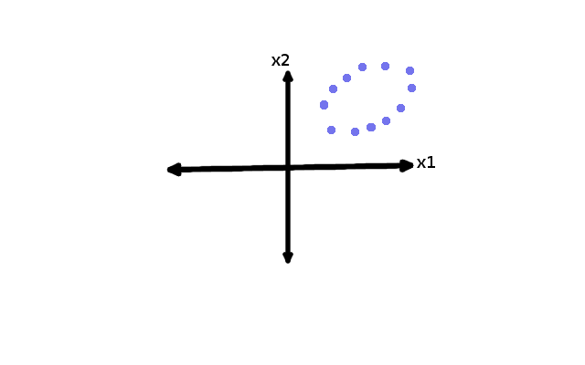

Dataset with two variables, x1 and x2

Now, we want to identify the first principal component that explains the highest amount of variance. Graphically, if a line is drawn that splits the oval lengthwise, that line signifies the component that explains the most variance:

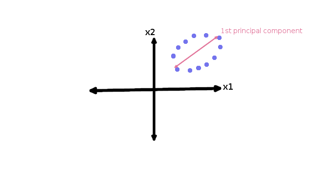

Finding the first principal component

\newpage

To find the second principal component, we find a second line that explain the next highest amount of variance. This must be orthogonal to the first principal component. The second principal component attempts to capture the variance that is not captured by the first principal component.

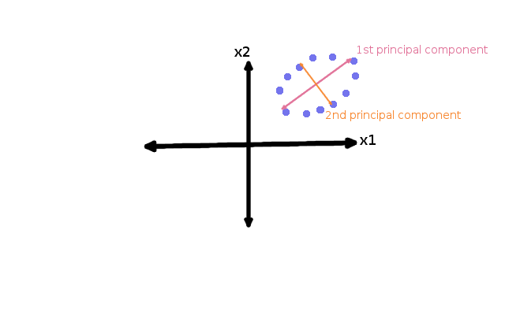

Finding the second principal component

As you can see in Figure 4, the two principal components are orthogonal and capture the elements of the data set.

\newpage

Thus, if PCA was performed on this dataset and the original dataset was projected onto the first two principal components, then no information would be lost. (A two-dimensional dataset is being transformed to a new two-dimensional dataset.) Since there are only two variables in the dataset, there can only be two principal components. Figure 5 shows what the original dataset projected onto the principal components looks like.

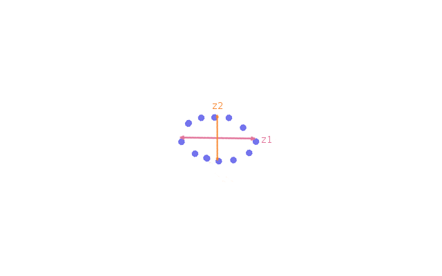

Original dataset projected onto the principal components

\newpage

For the weight lifting data set, we will look at the principal components (using commands from the `FactoMineR` package).

```r
wl.pca <- PCA(wl2[, -c(1,2,55)], graph = FALSE)
# This command runs PCA on the training set. Three variables have
# been removed- `user_name`, `num_window`, and `classe`. The predictors
# must be numerical in order to perform PCA, which is why `user_name`
# and `classe` were removed. The window numbers were removed because they
# do not contribute to any variance, they are just markers for new lifts.
```

The first ten principal components and the percentage of variance that each contributes.

|  | percentage of variance | cumulative percentage of variance |
| --- | --- | --- |
| comp 1 | 16.070155 | 16.07015 |
| comp 2 | 15.583292 | 31.65345 |
| comp 3 | 8.992345 | 40.64579 |
| comp 4 | 7.941611 | 48.58740 |
| comp 5 | 7.022997 | 55.61040 |
| comp 6 | 5.776076 | 61.38648 |
| comp 7 | 4.307617 | 65.69409 |
| comp 8 | 3.986191 | 69.68028 |
| comp 9 | 3.302367 | 72.98265 |
| comp 10 | 2.901580 | 75.88423 |

Apparently, the first five components contribute to a little more than half of the variance in our numerical predictors. The first ten principal components contribute about 76% of the variance.

Figure 6 shows some of the most important variables plotted against the first two principal components. As seen in the factor map, `yaw_belt`, `roll_belt`, `total_accel_belt`, `accel_belt_y`, and `accel_belt_z` would be the best at spreading out the data. It would be interesting to see what a physicist has to say about the variables and if it makes sense that these variables are most important for predicting the classifications of lift types.

\newpage

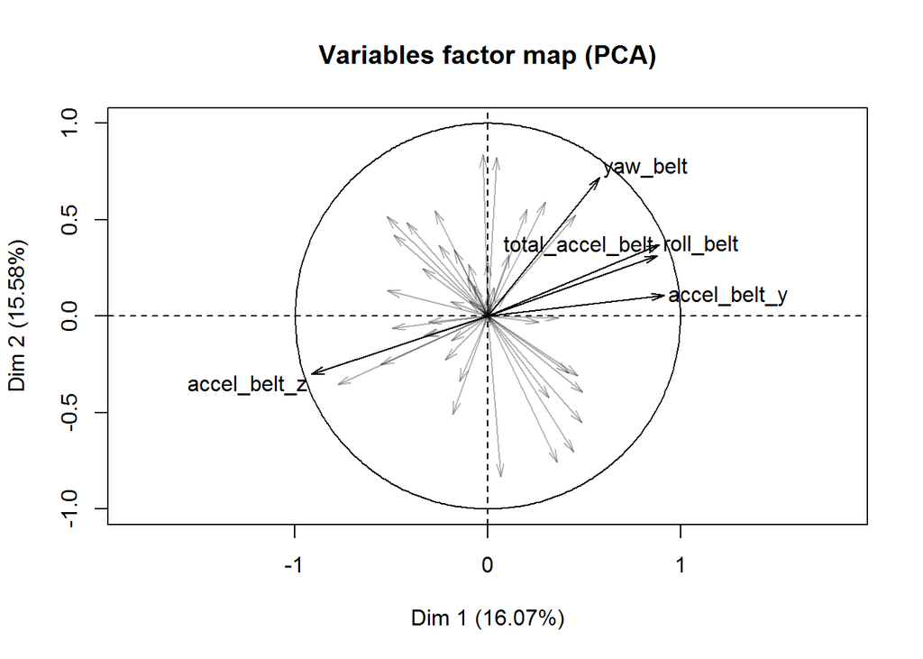

The plotting dimensions are determined by the first two principal compnents. The labeled variables are the five that are ‘closest’ to the plane of the these components.

\newpage

We can also look at the first three principal components and get a 3-dimensional cloud for each subject. (One outlier was removed in order to give a better depiction of the clouds.)

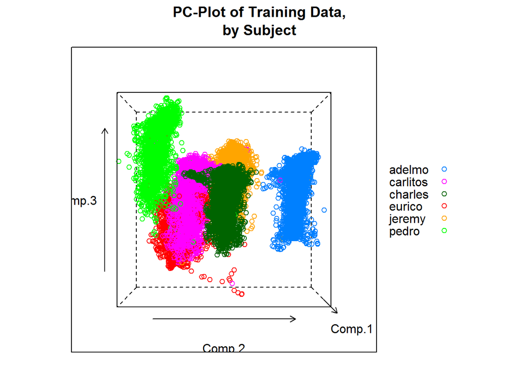

```r
cloud(Comp.1 ~ Comp.2 * Comp.3, groups = wl2$user_name,
      screen = list(x = 0, y = 0, z = 0),
      auto.key = list(space = "right"),
      main = "PC-Plot of Training Data,\nby Subject")
```

Each subject has distinct movement profiles, so it would be difficult to predict the movements of one subject from the movements of the other subjects. It is interesting to note that Adelmo and Pedro had two of the worst error rates from the random forest procedure and their clouds are removed from the others.

\newpage

# Bibliography

Amit, Yali; Geman, Donald (1997). *Shape quantization and recognition with randomized trees* (PDF). Neural Computation 9 (7): 1545–1588. doi:10.1162/neco.1997.9.7.1545.

Breiman, Leo, and Cutler, Adele. *Random Forests Leo Breiman and Adele Cutler.* Random Forests. 29 June 2007. Web. 20 Sept. 2015. https://www.stat.berkeley.edu/~breiman/RandomForests/cc_home.htm#intro

Breiman, Leo. *Random Forests.* Machine Learning 45.1 (2001): 5-32. Web. 20 Sept. 2015.

James, Gareth, Witten, Daniela, Hastie, Trevor and Tibshirani, Robert. *An Introduction to Statistical Learning with Applications in R*. 2013. Print.

Hamiltion, Laura D. *Introduction to Principal Component Analysis.* Introduction to Principal Component Analysis (PCA) -. N.p., 2 Nov. 2014

Ho, Tin Kam (1995). *Random Decision Forests* (PDF). Proceedings of the 3rd International Conference on Document Analysis and Recognition, Montreal, QC, 14–16 August 1995. pp. 278–282.

Ho, Tin Kam (1998). *The Random Subspace Method for Constructing Decision Forests* (PDF). IEEE Transactions on Pattern Analysis and Machine Intelligence 20 (8): 832–844. doi:10.1109/34.709601.

Mitchell, Tom. M. 1997. *Machine Learning.* New York: McGraw-Hill.

Steinberg, Dan. *Why Data Scientists Split Data into Train and Test.* Why Data Scientists Split Data into Train and Test. 3 Mar. 2014. Web. 27 Sept. 2015.

Velloso, Eduardo, Andreas Bulling, Hans Gellersen, Wallace Ugulino, and Hugo Fuks. *Qualitative Activity Recognition of Weight Lifting Exercises.* Proceedings of the 4th Augmented Human International Conference on - AH ’13 (2015).

White, Homer. *Predicting Movement-Types: Quick Model-Making with Random Forests.* Https://github.com/homerhanumat/WeightLifting. 4 Aug. 2015. Web. 1 Sept. 2015.

Witten, Ian H., and Eibe Frank. 2000. *Data Mining: Practical Machine Learing Tools and Techniques with Java Implementations.* San Diego, CA: Morgan Kaufmann.

Xie, Yihui. *Dynamic Documents with R and knitr*. 2014. Print.

http://mathworld.wolfram.com/Kurtosis.html

https://en.wikipedia.org/wiki/Random_forest